# Visual Data Story of Parking Patterns at Carlaw Student Village

## The Daily Flow of Carlaw Student Village

Understanding how parking capacity fluctuates is crucial for student residents. To figure out exactly what’s going on, I spent a few weeks tracking how many cars were parked in the lot at different times. By looking at the average number of cars for each day of the week, we can get a basic idea of when the lot is completely packed.

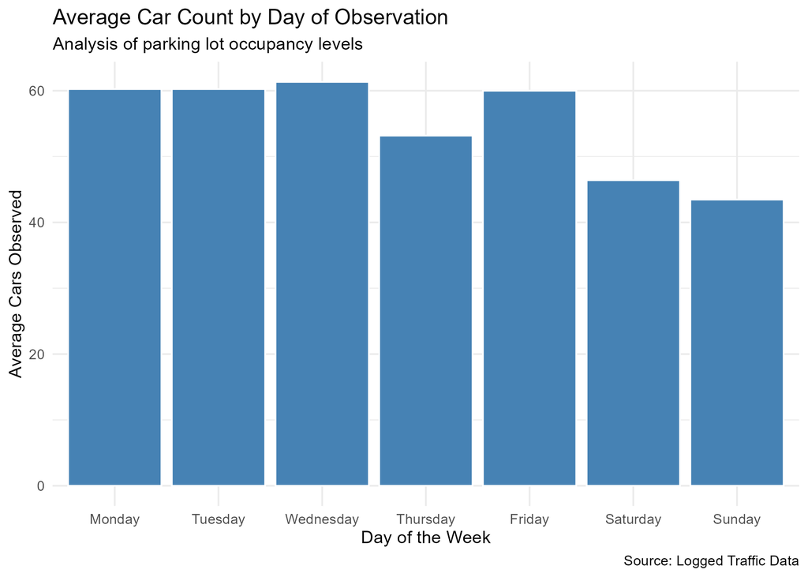

A bar chart titled ‘Average Car Count by Day of Observation’. The x-axis lists the days of the week from Monday to Sunday. The y-axis shows the average cars observed. The steel blue bars indicate the varying average parking lot occupancy levels throughout the week.

## Comparing Parking between Weekdays and Weekends

Just looking at daily averages doesn’t tell the whole story, though. an 8:00 AM on a Tuesday has a completely different vibe than an 8:00 AM on a Saturday. By breaking the data down into specific time chunks and splitting it into weekdays versus weekends, the real patterns start to show up. These boxplots let us see exactly how parking traffic shifts.

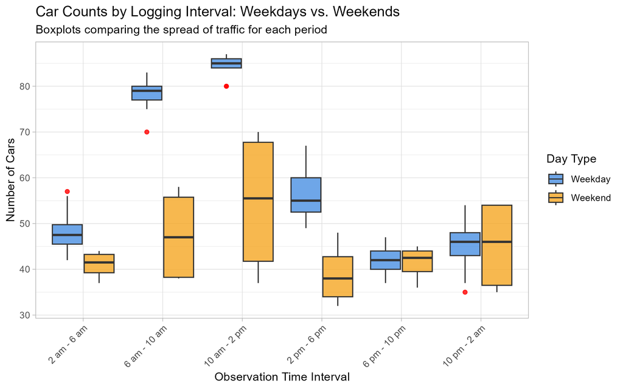

A side-by-side boxplot comparing car counts across six specific time intervals, from 2 am to 10 pm. The boxes are color-coded: blue for Weekdays and orange for Weekends. The chart shows the median, quartiles, and outliers of parking traffic for each time block, highlighting the differing patterns between week days and weekends.